# Capital Punishment in the U.S.

STT2860 Project 02 Fall 2022

Gracey, Natara, Evan

Tuesday, November 15, 2022 @ 04:41 PM

### Packages Used

```r
library(tidyverse)
```

### Read Data Files

```r
cappunish <- readRDS("cappunish.rds")
deathrowsize <- readRDS("deathrowsize.rds")
deathsentencesNC <- readRDS("deathsentencesNC.rds")
```

### Plot #1: How Many States Have Capital Punishment?

- Create a barplot for the variable `dp2`.
- Use `color =` and `fill =` to format the bars.
- Use `labs()` to add a title and better axis labels.
- Apply a built-in theme from **ggplot2** or **ggthemes**.
- You may optionally add a subtitle or caption to the plot.
- This plot should *not* have a visible legend anywhere on it.

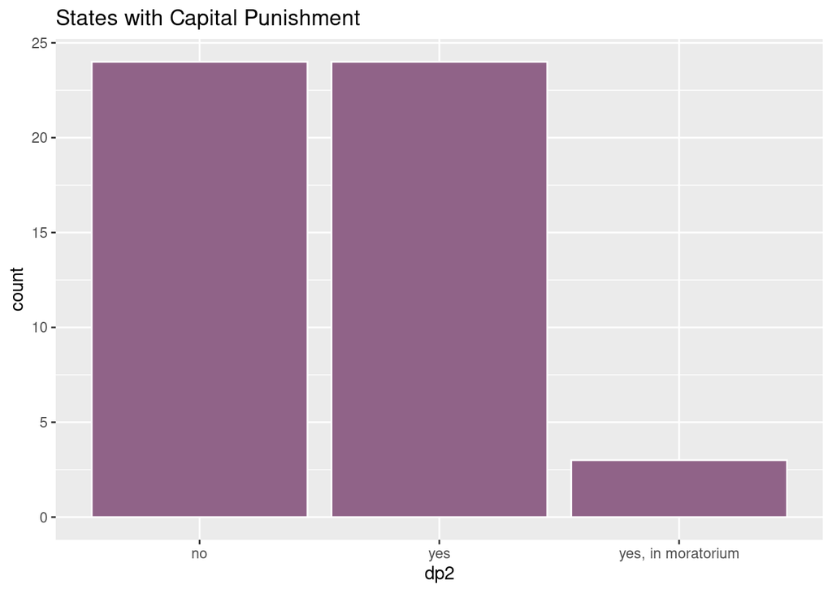

```r
ggplot(cappunish, aes(x = dp2)) +
  geom_bar(color = 'white', fill = "#906388") +
  labs(title = "States with Capital Punishment")
```

### Plot #2: Capital Punishment By Region of the U.S.

- Create a barplot for the variable `region`.
- Use `fill =` to shade each bar according to `dp2`.
- Change the `position =` to set each bar equal to 100%.
- Use `width =` to make the bars narrower than the default.
- Use `labs()` to add a title, axis labels, and a better legend label.
- Use `scale_fill_manual()` to choose a different color scheme for the plot.
- Use `theme()` to move the legend to the bottom of the plot instead of the right
- You may optionally add a subtitle, caption, or ggplot2 built-in theme to the plot.

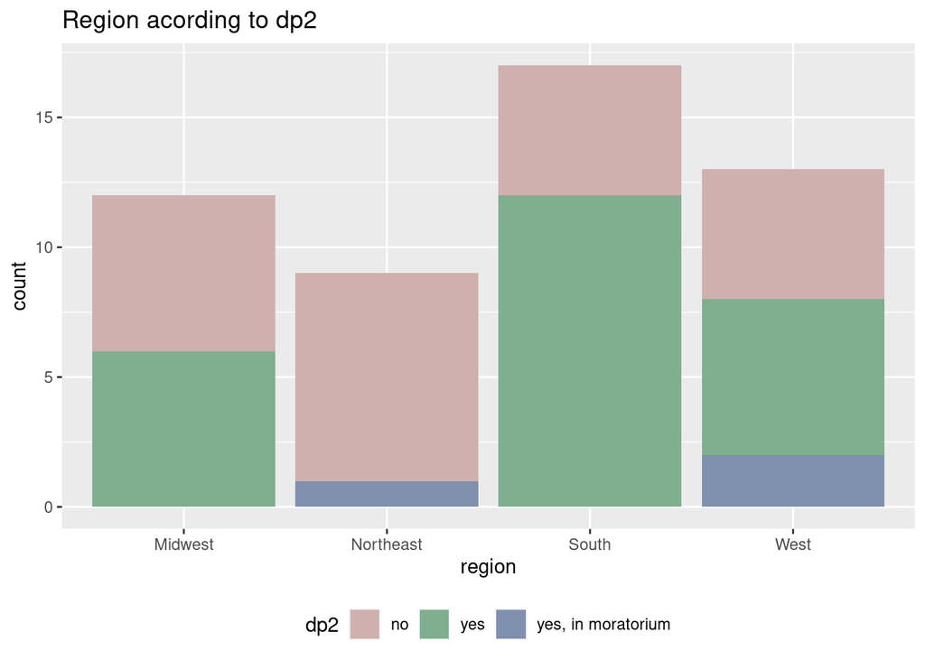

```r
ggplot(cappunish, aes(x = region, fill = dp2)) +
  geom_bar() +
  labs(title = "Region acording to dp2") +
  scale_fill_manual(values = c("#D0B0AF", "#80AF90", "#8090AF"))+
  theme(legend.position="bottom")
```

### Plot #3: Number of Prisoners on Death Row

- Create a barplot for the total number of prisoners (y) in each year (x).
- Fill the bars using the variable `decade` and outline them all in black.
- Set the width of all the bars so there is no visible gap in between them.
- Scale the x-axis to include a tick mark at each decade (1970, 1980, etc).
- Scale the y axis so that it is numbered 0, 500, 1000, 1500, 2000, etc.
- Use `labs()` to add or change the title, axis labels, and legend label.
- Use `theme()` to do the following:
  - center your title
  - set the plot background to white or blank
  - set all axis tick marks to transparent or blank
  - set the major x-axis gridlines to transparent or blank
  - set the major y-axis gridlines to light gray
- You may optionally change the bar color scheme used in your plot

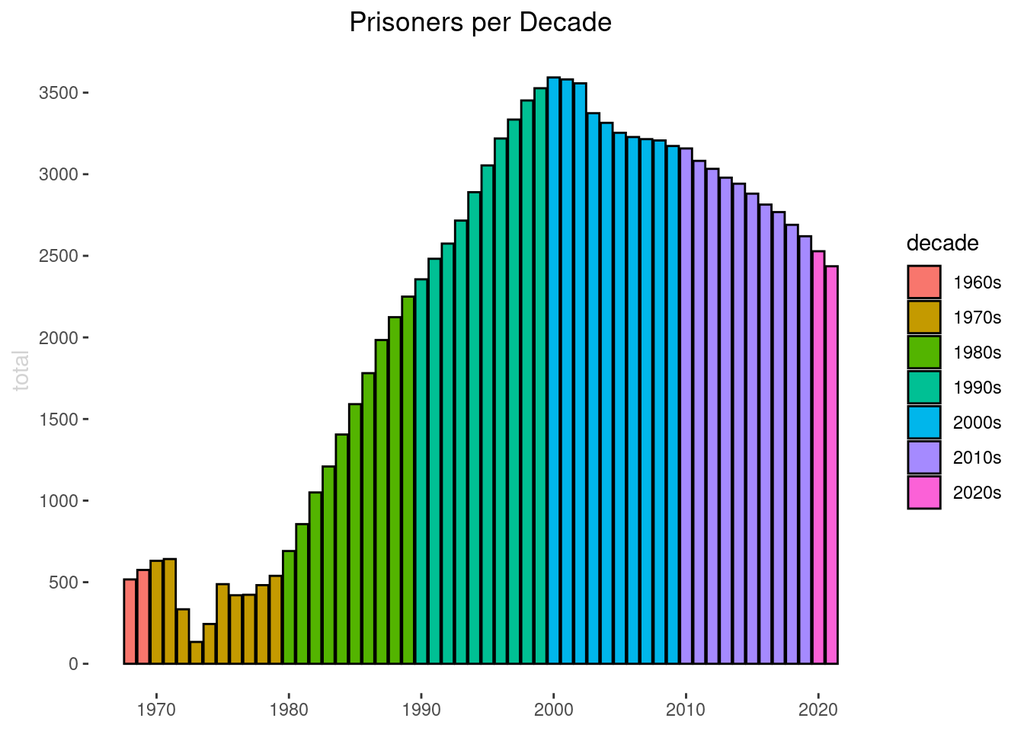

```r
ggplot(deathrowsize, aes(x = year, y = total, fill = decade)) +
  geom_col(color = "black") +
  scale_x_continuous(breaks = seq(1960, 2020, by = 10)) +
  scale_y_continuous(breaks = seq(0, 10000, by = 500)) +
  labs(title = "Prisoners per Decade") +
  theme(panel.background = element_blank()) +
  theme(plot.title = element_text(hjust = 0.5)) +
  theme(axis.title.x = element_blank()) +
   theme(axis.title.y = element_text(color = "light gray"))
```

### Plot #4: Number of Executions Since 1976

- Create a violin plot for the variable `post1976` (use `y = 0`)
- Add a boxplot and set the width so it fits inside the violin plot
- Fill each plot with a color of your choice (be colorblind-aware)
- Scale the x-axis of the plot so that it counts in increments of 25
- Get rid of all y-axis markings/gridlines using `scale_y_continuous()`
- Add a title, x-axis label, and a caption to identify the large outlier
- Add the built-in theme `theme_linedraw()` or `theme_minimal` to the plot

Hint: You can use the `NULL` vector in functions like `scale_y_continuous()`

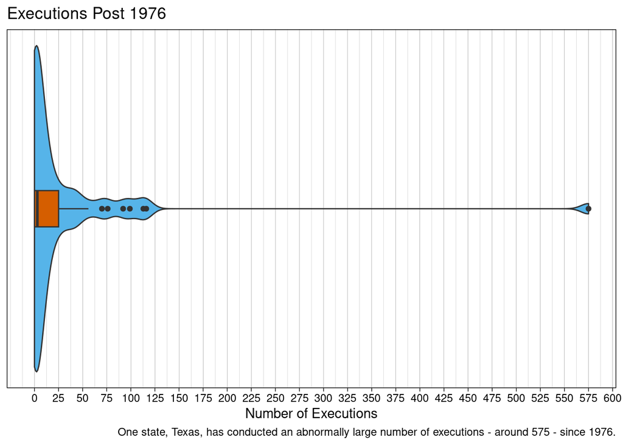

```r
ggplot(cappunish, aes(y = 0, x = post1976)) +
geom_violin(fill = "#56B4E9")  +
  geom_boxplot(fill = "#D55E00", width = .1) +
   scale_x_continuous(breaks = seq(0,2000, by = 25)) +
    scale_y_continuous(breaks = NULL) +
  labs(title = "Executions Post 1976", x = "Number of Executions", caption = "One state, Texas, has conducted an abnormally large number of executions - around 575 - since 1976.") +
  theme_linedraw() +
  theme(axis.title.y = element_blank())
```

### Plot #5: Death Sentences in NC Since 1976

Create a time series plot of death sentences in North Carolina. Use three geometries on this plot: `geom_area()`, `geom_line()` and `geom_point()`. Use `geom_vline()` to add a vertical line for 2001. The significance of this year is that the General Assembly modified the death penalty statute in several ways, including giving prosecutors the discretion to *not* seek the death penalty in cases where it previously would have been mandatory. Format and label your plot in such a way that the information it conveys would be clear to the reader (i.e., the plot is reasonably stand-alone).

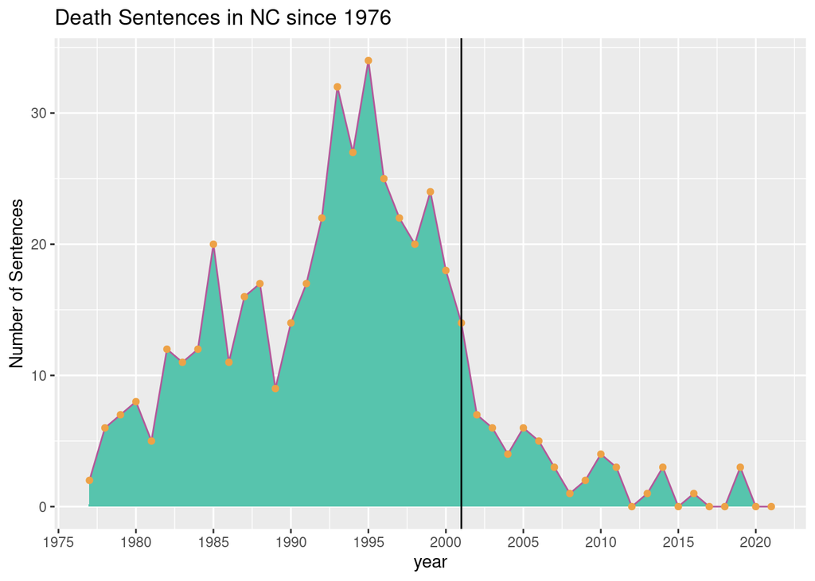

```r
ggplot(deathsentencesNC, aes(x = year, y = sentences)) +
  geom_area(fill = "#57C4AD") +
  geom_line(color = "#B3589a") +
  geom_point(color = "#EDA247") +
  geom_vline(xintercept = 2001) +
  scale_x_continuous(breaks = seq(1960,2025, by = 5)) +
labs(title = "Death Sentences in NC since 1976", y = "Number of Sentences")
```

### Information Conveyed by Your Plots

List two pieces of information you can learn or comparisons you can make from each plot above.

#### Plot #1

- Item 1: learned how many states have capital punishment
- Item 2: learned how many states have capital punishment under moratorium, meaning it temporarily stopped

#### Plot #2

- Item 1: learned what regions where there is more states with capital punishment
- Item 2: learned what regions where capital punishment is in moratorium

#### Plot #3

- Item 1: learned that the total number of prisoners was lowest in the 70’s
- Item 2: learned that the total number of prisoners was highest at the beginning of the 2000’s

#### Plot #4

- Item 1: learned how many executions there has been since 1976
- Item 2: can see which states have had the most executions in 1976

#### Plot #5

- Item 1: the number of death sentences was the highest in 1995
- Item 2: the number of death sentences has declined since 2001